# Image Analysis of Multi-Spectral and Polarimetric SAR Imagery with Open Source Tools (Part 2)

## Mort Canty (mort.canty@gmail.com)

## ZFL Bonn, April 2016

# 3. SAR and Polarimetric SAR Images

### SAR imaging geometry

[figure not shown]

(Source: Richards (2009) Remote Sensing with Imaging Radar)

### Slant and ground range

[figure not shown]

(Source: Richards (2009) Remote Sensing with Imaging Radar)

### Radar ranging

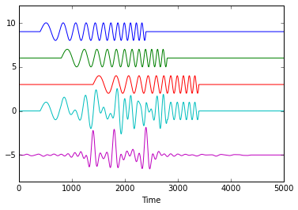

```python
%matplotlib inline
from numpy import *
import matplotlib.pyplot as plt

def chirp(t,t0):
    result = 0.0*t
    idx = array(range(2000))+t0
    tt = t[idx] - t0
    result[idx] = sin(2*math.pi*2e-3*(tt+1e-3*tt**2))
    return result

t = array(range(5000))
plt.plot(t,chirp(t,400)+9)
plt.plot(t,chirp(t,800)+6)
plt.plot(t,chirp(t,1400)+3)
signal = chirp(t,400)+chirp(t,800)+chirp(t,1400)
kernel = chirp(t,0)[:2000]
kernel = kernel[::-1]
plt.plot(t,signal)
plt.plot(0.003*convolve(signal,kernel,\
                                 mode='same')-5)
plt.xlabel('Time')
plt.ylim((-8,12))
plt.show()
```

### Synthetic aperture principle

[figure not shown]

(Source: Richards (2009) Remote Sensing with Imaging Radar)

### SAR resolution

[figure not shown]

(Source: Richards (2009) Remote Sensing with Imaging Radar)

The power received by a radar transmitting/receiving antenna reflected from a distributed (as opposed to point) target a distance $D$ from the antenna is given by

$$ P_R = {P_TG_TG_R\lambda^2\sigma^o\Delta_a\Delta_r\over (4\pi)^3D^4}\ [W],\quad (1) $$

where $P_T$ is the transmitted power $[W\cdot m^{-2}]$, $\lambda$ is the operating wavelength~$[m]$, $G_T(G_R)$ is the transmitting (receiving) antenna gain, $\Delta_a(\Delta_r)$ is the azimuth (ground range) resolution $[m]$ and $\sigma^o$ is the unitless scattering coefficient (referred to as the {\it radar cross section}) of the target surface. The scattering coefficient is related to the (bio)physical properties of the surface being irradiated, notably its water content.

### Polarimetric SAR

We will be concerned primarily with fully and partially *polarimetric SAR* data. A full, or *quad*, polarimetric SAR measures a $2\times 2$ *scattering matrix* $S$ at each resolution cell on the ground. The scattering matrix relates the incident and the backscattered electric fields $E^i$ and $E^b$ according to

$$ E^b = S E^i \quad\hbox{or}\quad \pmatrix{E_h^b \cr E_v^b} =\pmatrix{s_{hh} & s_{hv}\cr s_{vh} & s_{vv}}\pmatrix{E_h^i \cr E_v^i}.\quad (2) $$

Here $E_h^{i(b)}$ and $E_v^{i(b)}$ denote the horizontal and vertical components of the incident (backscattered) oscillating electric fields directly at the target. These can be deduced from the transmitted and received radar signals via the so-called *far-field* approximations. If both horizontally and vertically polarized radar pulses are emitted and discriminated, then they determine, from Equation (2), the four complex scattering matrix elements.

### Complex numbers

A complex number is an expression of the form $z=a+ib$, where $i^2=-1$. The *real part* of $z$ is $a$ and the *imaginary part* is $b$. The number $z$ can be represented as a point or vector in the *complex plane* with the real part along the $x$-axis and the imaginary part along the $y$-axis. Complex number addition then corresponds to addition of two-dimensional vectors:

$$ (a_1 + i b_1) + (a_2+i b_2) = (a_1+a_2) + i(b_1+b_2). $$

The *complex conjugate* of $z$ is $z^*=a-i b$. Thus

$$ z^*z = (a-i b)(a+i b) = a^2+b^2 = |z|^2, $$

where $|z|=\sqrt{a^2+b^2}$ is the *magnitude* of the complex number $z$. If $\theta$ is the angle that $z$ makes with the real axis, then

$$ z = a + i b = |z|\cos(\theta) + i |z|\sin(\theta). $$

From the well-known *Euler's Theorem* we can write this as

$$ z = |z|e^{i\theta}. $$

Complex numbers provide a convenient representation for the amplitude $E$ of an electric field:

$$ E = |E|cos(\omega t + \phi) = {\rm Re}\left(|E|e^{i (\omega t +\phi)}\right), $$

where $\omega = 2\pi f$ and $\phi$ are the angular frequency and phase of the radiation and Re denotes real part. It is usually convenient to work exclusively with complex amplitudes $|E|e^{i (\omega t +\phi)}$, bearing in mind that only the real part is physically significant. When the oscillating electric fields are described by complex numbers in this way, the scattering matrix elements are also complex.

A full polarimetric, or *quad polarimetric* SAR image then consists of four complex bands

$$ s_{hh}, s_{hv}, s_{vh}, s_{vv}, $$

one for each pixel-wise determination of an element of the scattering matrix. So-called *reciprocity*, which normally applies to natural targets, implies that

$$ s_{hv} = s_{vh} $$

so we might represent a measured quad pol pixel by the complex vector

$$ s = \pmatrix{s_{hh} \cr \sqrt{2}s_{hv} \cr s_{vv} }. $$

The squared amplitudes of the scattering coefficients $|s_{hh}|^2, 2|s_{hv}|^2, |s_{vv}|^2$ constitute the radar cross sections for each polarization combination. These in turn replace $\sigma^o$ in Equation (1) and determine the received power in each polarization channel.

### Speckle statistics

**(snap)**

The intensity of the backscattered signal in a polarimetric band is exponentially distributed. The argument runs as follows:

Even when the properties of the reflecting surface are uniform, random irregularities on the wavelength scale within the imaged pixel will act like a very large number of *incremental scatterers*, leading to a random superposition of small scattering amplitudes. These in turn combine coherently to form the backscattered signal and are responsible for speckle. A simple model for this effect is to write the backscattered amplitude in the form

$$ E^b = {E\over\sqrt{n}}\sum_{k=1}^n e^{i\phi_k}. $$

Here we assume that the only effect of the incremental scatterers is to introduce local random phase shifts $\phi_k$, $k=1\dots n$, in an overall scattered signal amplitude $E$. The phase shifts may be considered to be uniformly distributed on the interval $[-\pi,\pi]$, so that we have

$$ |E^b|^2 = {|E|^2\over n}\sum_k\sum_\ell e^{i(\phi_k-\phi_\ell)} ={|E|^2\over n}\sum_k e^{i(\phi_k-\phi_k)} = |E|^2. $$

We can express the real and imaginary parts in the form

$$ {\rm Re}(E^b) = {E\over\sqrt{n}}\sum_k \cos\phi_k = {E\over\sqrt{n}} X\ $$$$ {\rm Im}(E^b) = {E\over\sqrt{n}}\sum_k \sin\phi_k = {E\over\sqrt{n}} Y, $$

where

$$ X=\sum_k\cos\phi_k, \quad Y=\sum_k\sin\phi_k. $$

Now the intensity of the backscattered signal can be written

$$ |E^b|^2 = [{\rm Re}(E)]^2 + [{\rm Im}(E)]^2 = E^2{1\over n}(X^2+Y^2). $$

We can think of $X$ and $Y$ as random variables. Since the sines and cosines contributing to $X$ and $Y$ are distributed symmetrically about zero, the means vanish:

$$ \langle X\rangle = \langle Y\rangle = 0. $$

Furthermore,

$$ {\rm var}(X) = \langle X^2\rangle - \langle X\rangle^2 = \sum_k\sum_{\ell}\langle\cos\phi_k\cos\phi_\ell\rangle $$$$ = \sum_k \langle\cos^2\phi_k\rangle = \sum_k\langle{1\over 2}(\cos 2\phi_k+1)\rangle = {n\over 2}, $$

with the same result for ${\rm var}(Y)$. Moreover, $X$ and $Y$ are uncorrelated:

$$ {\rm cov}(X,Y) = \langle XY\rangle -\langle X\rangle\langle Y\rangle = \sum_k\sum_{\ell}\langle\cos\phi_k\sin\phi_\ell\rangle = 0. $$

Both $X$ and $Y$ are superpositions of a large number of identically distributed random variables ($\cos\phi_k$ and $\sin\phi_k$). According to the *Central Limit Theorem* they independently and normally distributed with zero mean and variance $\sigma^2=n/2$. The joint probability density of $X$ and $Y$ is therefore the bivariate distribution with

$$ \mu = \pmatrix{0\cr0},\quad \Sigma = {n\over 2}\pmatrix{1 & 0\cr 0 & 1} $$

that is,

$$ p(x,y) = {1\over 2\pi (n/2)}\exp\left(-{1\over 2(n/2)}(x^2+y^2)\right). $$

With $z = x+i y$, this can be written in the form

$$ p(z) = {1\over\pi n}\exp\left(-z^*\left({1\over n}\right)z\right). $$

This shows that the complex random variable $Z= X + i Y$, and hence the backscattered amplitude

$$ E^b = {E\over\sqrt{n}} (X + i Y) = {E\over\sqrt{n}}Z, $$

has a *complex normal distribution*.

The sum $U$ of the squares of the *standardized* random variables $X$ and $Y$,

$$ U = {X^2\over n/2} + {Y^2\over n/2} = {2\over n}(X^2+Y^2), $$

is chi-square distributed with 2 degrees of freedom, that is,

$$ p_u(u) = p_{\chi^2;2}(u) = {1\over 2} e^{-u/2}. $$

$$ |E^b|^2 = E^2 U/2. $$

A measurement of a radar cross section, say $|s_{hh}|^2$, derived from the emitted and received polarized signal intensities will have the same exponential distribution. In other words, if $z$ is the measured intensity, $x = |s_{hh}|^2$ is the underlying signal and $u$ is the speckle, then

$$ z = x u/2. $$

Applying the rule

$$ p_z(z) = p_u(u)\left |{du\over dz}\right | = {1\over 2} e^{-u/2}{2\over x} = {1\over x} e^{-z/x} $$

### Multi-look data

The measured amplitude signal for a quad pol image pixel is

$$ s = \pmatrix{s_{hh} \cr \sqrt{2}s_{hv} \cr s_{vv} }. $$

The total instensity is referred to as the *span*,

$$ {\rm span} = s^+ s = |s_{hh}|^2 + 2|s_{hv}|^2 + |s_{vv}|^2, $$

and the corresponding gray-scale image as the *span image*.

Multi-look processing essentially corresponds to the averaging of neighbourhood pixels, with the objective of reducing speckle and compressing the data. If m measurements such as

$$ z(\nu) = |s_{hh}|_\nu^2 $$

are averaged to give

$$ \bar z = {1\over m}\sum_{\nu=1}^m z(\nu) $$

then the sum

$$ m\bar z = \sum_{\nu=1}^m z(\nu) $$

is gamma dstributed with $\alpha=m$ and $\beta = x$. So its mean and variance are

$$ \alpha\beta = mx,\quad \alpha\beta^2= mx^2. $$

Then the mean of the multi-look pixel $\bar z$ is

$$ \langle\bar z\rangle = {1\over m}mx = x $$

and its variance is

$$ {\rm var} (\bar z) = {\rm var}\left({1\over m}\sum_{\nu=1}^m z(\nu)\right) = {1\over m^2}mx^2 = {x^2\over m}.\quad (1) $$

We see that the variance of the look-averaged image decreases inversely as the number of looks.

In real SAR imagery, the neighborhood pixel intensities contributing to the look average will be correlated to some extent. This is accounted for by defining an *equivalent number of looks* (ENL) whose definition is motivated by Equation (1), that is, by solving it for $m$:

$$ {\rm ENL} = m = {x^2\over {\rm var}(\bar z)}. $$

The ENL can be estimated in homogeneous regions of an image, where the contribution of speckle to image statistics may be expected to dominate.

### Polarimetric matrix representations and pre-processing

Another representation of the polarimetric signal is the *complex covariance matrix* $c$, obtained by taking the complex outer product of $s$ with itself:

$$ c = s s^+ = \pmatrix{ |s_{hh}|^2 & \sqrt{2}\ s_{hh}s_{hv}^* & s_{hh}s_{vv}^* \cr \sqrt{2}\ s_{hv}s_{hh}^* & 2|s_{hv}|^2 & \sqrt{2}\ s_{hv}s_{vv}^* \cr s_{vv}s_{hh}^* & \sqrt{2}\ s_{vv}s_{hv}^* & |s_{vv}|^2 }. $$

The diagonal elements of $c$ are real numbers, and their sum is the span. The off-diagonal elements are complex. The covariance matrix representation contains all of the information in the polarized signal.

It can also be averaged over the number of looks to give

$$ \bar{c} ={1\over m}\sum_{\nu=1}^m s(\nu)s(\nu)^+ = \langle s s^+ \rangle $$

or

$$ \bar{c}= \pmatrix{ \langle |s_{hh}|^2\rangle & \sqrt{2}\langle s_{hh}s_{hv}^*\rangle & \langle s_{hh}s_{vv}^*\rangle \cr \sqrt{2}\langle s_{hv}s_{hh}^*\rangle & \langle 2|s_{hv}|^2\rangle & \sqrt{2}\langle s_{hv}s_{vv}^*\rangle \cr \langle s_{vv}s_{hh}^*\rangle & \sqrt{2}\langle s_{vv}s_{hv}^*\rangle & \langle |s_{vv}|^2\rangle }. $$

Rewriting the first equation above,

$$ m\bar{c} = \sum_{\nu=1}^m s(\nu)s(\nu)^+. $$

This is seen to be a realization of a complex sample matrix with a complex Wishart distribution with $3\times 3$ covariance matrix $\Sigma$ and $m$ degrees of freedom, provided that the vectors $s(\nu)$ are independent and drawn from a complex multivariate normal distribution.As already mentioned, the $s(\nu)$ will generally be correlated. In order to account for this, the complex Wishart distribution is often parameterized with ENL (rather than $m$) degrees of freedom. The complex Wishart distribution of $m\bar c$ will be exploited later for change detection.

Another representation is the *coherency vector*

$$ t = \pmatrix{{1\over \sqrt{2}}(s_{hh}+s_{vv}) \cr {1\over\sqrt{2}}(s_{hh}-s_{vv}) \cr \sqrt{2}s_{hv} }, $$

and the corresponding look-averaged *coherency matrix*

$$ \bar{k} = {1\over m}\sum_{\nu=1}^m t(\nu)t(\nu)^+ = \langle t t^+\rangle. $$

$m\bar k$ is also complex Wishart distributed.

**(snap)**

```python
ls -l /home/imagery/RS2_OK5491_PK71074_DK68879_FQ21_20100426_172459_HH_VV_HV_VH_SLC
```

```
total 336284
-rw------- 1 root root   741610 Apr 27  2010 BrowseImage.tif
-rw------- 1 root root    44218 Oct  2  2009 DFAIT_RS2 EULA_Single User License.pdf
-rw------- 1 root root      623 Jun 15  2015 GEARTH_POLY.kml
drwxrwxr-x 3 root root     4096 Apr 12 09:57 T3/
-rw------- 1 root root    89600 Apr 28  2010 Thumbs.db
-rw------- 1 root root 85731468 Apr 27  2010 imagery_HH.tif
-rw------- 1 root root 85731468 Apr 27  2010 imagery_HV.tif
-rw------- 1 root root 85731468 Apr 27  2010 imagery_VH.tif
-rw------- 1 root root 85731468 Apr 27  2010 imagery_VV.tif
-rw------- 1 root root    49475 Apr 27  2010 lutBeta.xml
-rw------- 1 root root    49475 Apr 27  2010 lutGamma.xml
-rw------- 1 root root    49475 Apr 27  2010 lutSigma.xml
drwxrwxr-x 3 root root     4096 Dec 15 11:20 polsarpro/
-rw------- 1 root root   119099 Apr 27  2010 product.xml
-rw------- 1 root root   160314 Jun 15  2015 product_header.txt
-rw------- 1 root root    15152 Jun 15  2015 product_lut.bin
-rw------- 1 root root    49765 Jun 15  2015 product_lut.txt
-rw------- 1 root root      316 Mar 24  2010 readme.txt
drwx------ 2 root root     4096 Sep 17  2014 schemas/
```

```python
cd /home/imagery/RS2_OK5491_PK71074_DK68879_FQ21_20100426_172459_HH_VV_HV_VH_SLC
```

```
/home/imagery/RS2_OK5491_PK71074_DK68879_FQ21_20100426_172459_HH_VV_HV_VH_SLC
```

```python
ls -l polsarpro/T3
```

```
total 61476
-rw-rw-r-- 1 root root 6986432 Dec 15 11:20 T11.bin
-rw-rw-r-- 1 root root     245 Apr 20 08:16 T11.bin.hdr
-rw-rw-r-- 1 root root 6986432 Dec 15 11:20 T12_imag.bin
-rw-rw-r-- 1 root root     246 Dec 15 11:20 T12_imag.bin.hdr
-rw-rw-r-- 1 root root 6986432 Dec 15 11:20 T12_real.bin
-rw-rw-r-- 1 root root     241 Dec 15 11:20 T12_real.bin.hdr
-rw-rw-r-- 1 root root 6986432 Dec 15 11:20 T13_imag.bin
-rw-rw-r-- 1 root root     246 Dec 15 11:20 T13_imag.bin.hdr
-rw-rw-r-- 1 root root 6986432 Dec 15 11:20 T13_real.bin
-rw-rw-r-- 1 root root     241 Dec 15 11:20 T13_real.bin.hdr
-rw-rw-r-- 1 root root 6986432 Dec 15 11:20 T22.bin
-rw-rw-r-- 1 root root     241 Dec 15 11:20 T22.bin.hdr
-rw-rw-r-- 1 root root 6986432 Dec 15 11:20 T23_imag.bin
-rw-rw-r-- 1 root root     246 Dec 15 11:20 T23_imag.bin.hdr
-rw-rw-r-- 1 root root 6986432 Dec 15 11:20 T23_real.bin
-rw-rw-r-- 1 root root     241 Dec 15 11:20 T23_real.bin.hdr
-rw-rw-r-- 1 root root 6986432 Dec 15 11:20 T33.bin
-rw-rw-r-- 1 root root     241 Dec 15 11:20 T33.bin.hdr
-rw-rw-r-- 1 root root      96 Apr 20 08:16 config.txt
-rw-rw-r-- 1 root root   18773 Dec 15 11:20 metadata.xml
```

```python
!/home/mapready.sh 20100426 rs2quad
```

```
Geocoding polSARpro multilook polarimetric matrix image with mapready ...
dos2unix: converting file /home/imagery/RS2_OK5491_PK71074_DK68879_FQ21_20100426_172459_HH_VV_HV_VH_SLC/polsarpro/T3/config.txt to Unix format ...
Original SLC image dimensions:      rows 5539  cols 3788
After multi-looking with polSARpro: rows 1384  cols 1262
Azimuth looks: 4
Range looks:   3
***** processing polSARpro polarimetric matrix image:
***** /home/imagery/RS2_OK5491_PK71074_DK68879_FQ21_20100426_172459_HH_VV_HV_VH_SLC
***** ...
***** Done, see mapready.log
***** Combining into a single image file ...
Overwriting previous combined image
=========================
     Ingest SAR
=========================
Wed Apr 20 08:42:35 2016
Directory /home/imagery/RS2_OK5491_PK71074_DK68879_FQ21_20100426_172459_HH_VV_HV_VH_SLC_MapReady/T3/
writing band 1
writing band 2
writing band 3
writing band 4
writing band 5
writing band 6
writing band 7
writing band 8
writing band 9
elapsed time: 1.35338807106
Multiband image is /home/imagery/RS2_OK5491_PK71074_DK68879_FQ21_20100426_172459_HH_VV_HV_VH_SLC_MapReady/T3/polSAR.tif
```

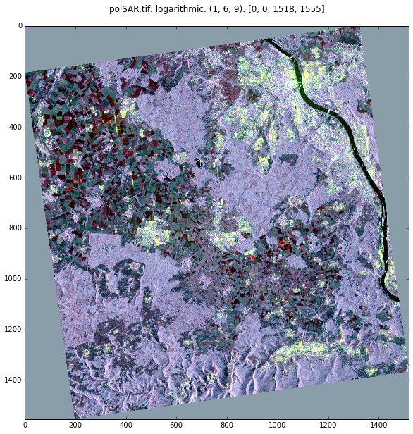

```python
run /home/dispms -f /home/imagery/RS2_OK5491_PK71074_DK68879_FQ21_20100426_172459_HH_VV_HV_VH_SLC_MapReady/T3/polSAR.tif -p [1,6,9]
```

### The gamma MAP filter

We have seen that an $m$ look-averaged SAR intensity image is described by the random variable $Z$ with mean $\langle Z\rangle=x$ and variance ${\rm var}(Z) = x^2/m$, where $x$ is the underlying signal. Since $Z$ is gamma-distributed, its parameters $\alpha$ and $\beta$ must satisfy

$$ \alpha\beta = x,\quad \alpha\beta^2 = x^2/m, $$

from which follows $\alpha= m$ and $\beta = x/m$. The probability density function of $Z$ for given value of $x$ is therefore

$$ p(z\mid x) = {1\over (x/m)^m\Gamma(m)}z^{m-1}e^{-zm/x}.\quad (1) $$

Let

$$ z = xv. $$

Then $v$ has the probability distribution

$$ p_v(v) = p_z(z)\cdot\left|{dz\over dv}\right| = {1\over (x/m)^m\Gamma(m)}x^{m-1}v^{m-1}e^{-mv}\cdot x = {m^m\over \Gamma(m)}v^{m-1}e^{-vm}. $$

which is the gamma distribution with mean 1 and variance $1/m$. Because of this special *multiplicative noise* nature of speckle, conventional smoothing filters of the kind used for multispectral imagery are not particularly suitable as an aid to SAR image interpretation.

According to Bayes' Theorem, the posterior probability for signal $x$, given observation $z$, is

$$ {\rm Pr}(x\mid z) = { p(z\mid x){\rm Pr}(x)\over p(g) },\quad (2) $$

where $p(z\mid x)$ is given by Equation (1). This formulation allows us to include prior knowledge of the signal statistics (or texture) if available. An empirical statistical model for $x$ is suggested by measurements of backscatter from ocean waves:

$$ {\rm Pr}(x) \sim \left({\alpha\over\mu}\right)^\alpha {x^{\alpha-1}\over\Gamma(\alpha)}e^{-\alpha x/\mu}. \quad (3) $$

This is just the gamma probability density with $\beta=\mu/\alpha$, and hence with mean $\alpha\beta= \mu$ and variance

$$ {\rm var}(x) = \alpha\beta^2 = \mu^2/\alpha. $$

The parameters $\mu$ and $\alpha$ must be estimated from the image intensity data.

Combining Equations (1), (2) and (3) and neglecting the total probability $p(g)$, which doesn't depend on $x$, the posterior probability for $x$ given measurement $z$ is

$$ {\rm Pr}(x\mid z) \sim {1\over (x/m)^m\Gamma(m)}z^{m-1}e^{-zm/x}\left({\alpha\over\mu}\right)^\alpha {x^{\alpha-1}\over\Gamma(\alpha)}e^{-\alpha x/\mu} =: L $$

We get the *maximum a posteriori* (MAP) value for $x$ given the observed pixel intensity $z$ by maximizing $\log L$ with respect to $x$:

$$ {d\over dx}\log L = -m/x + mz/ x^2 + (\alpha-1)/x - \alpha/\mu = 0. $$

This leads to a quadratic equation for the most probable signal intensity $x$,

$$ {\alpha\over\mu}x^2 + (m+1-\alpha)x - mz = 0, $$

where the parameters $\mu$ and $\alpha$ are estimated locally in an $n\times n$ window:

$$ \mu \approx \langle z\rangle_n $$

and

$$ \alpha \approx {\mu^2\over {\rm var}(x)}. $$

We can get ${\rm var}(x)$ as follows. Recall that $z = xv$ where $\langle v\rangle = 1$ and ${\rm var}(v) = 1/m$. Since signal $x$ and speckle noise $v$ are independent,

$$ \langle z^2\rangle_n = \langle x^2\rangle_n\langle v^2\rangle_n $$

or

$$ {\rm var}(z)+\langle z\rangle_n^2 = ({\rm var}(x) + \langle x\rangle_n^2)({\rm var}(v) + \langle v\rangle_n^2). $$

Solving for ${\rm var}(x)$ we obtain, with $\langle x\rangle_n = \langle z\rangle_n =\mu$,

$$ {\rm var}(x) = {{\rm var}(z) - {1\over m}\mu^2 \over 1 + {1\over m}}. $$

```python
run /home/gamma_filter -h
```

```
    Usage:
    ------------------------------------------------
    python /home/gamma_filter.py [-h] [-p] [-d dims] filename enl

    Run a gamma MAP filter in the diagonal elements of a C or T matrix
     Set flag -p for parallel execution on (at least 2) IPython engines
    ------------------------------------------------
```

**Directional filter**

[figure not shown]

```python
run /home/gamma_filter -d [400,400,400,400] /home/imagery/RS2_OK5491_PK71074_DK68879_FQ21_20100426_172459_HH_VV_HV_VH_SLC_MapReady/T3/polSAR.tif 12
```

```
=========================
    GAMMA MAP FILTER
=========================
Wed Apr 20 08:43:04 2016
infile:  /home/imagery/RS2_OK5491_PK71074_DK68879_FQ21_20100426_172459_HH_VV_HV_VH_SLC_MapReady/T3/polSAR.tif
equivalent number of looks: 12.000000
filtering 3 diagonal matrix element bands ...
band 1  row 50
band 1  row 100
band 1  row 150
band 1  row 200
band 1  row 250
band 1  row 300
band 1  row 350
band 2  row 50
band 2  row 100
band 2  row 150
band 2  row 200
band 2  row 250
band 2  row 300
band 2  row 350
band 3  row 50
band 3  row 100
band 3  row 150
band 3  row 200
band 3  row 250
band 3  row 300
band 3  row 350
result written to: /home/imagery/RS2_OK5491_PK71074_DK68879_FQ21_20100426_172459_HH_VV_HV_VH_SLC_MapReady/T3/polSAR_gamma.tif
elapsed time: 99.0732860565
```

```python
run /home/gamma_filter -p -d [400,400,400,400] /home/imagery/RS2_OK5491_PK71074_DK68879_FQ21_20100426_172459_HH_VV_HV_VH_SLC_MapReady/T3/polSAR.tif 12
```

[output not shown]

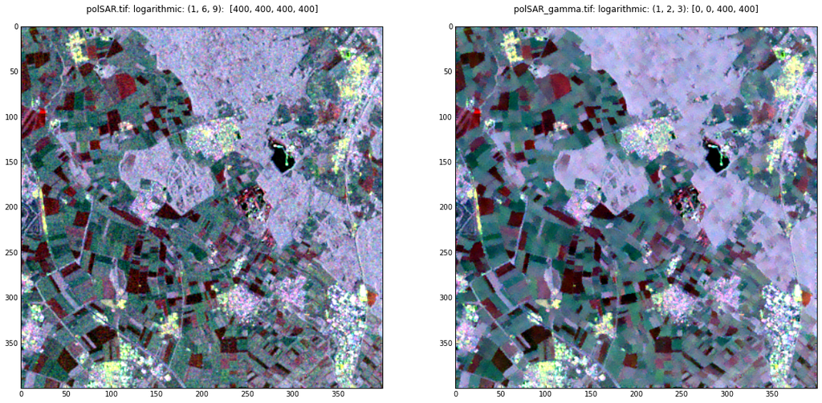

```python
run /home/dispms -p [1,6,9] -P [1,2,3] -d [400,400,400,400] \
-f /home/imagery/RS2_OK5491_PK71074_DK68879_FQ21_20100426_172459_HH_VV_HV_VH_SLC_MapReady/T3/polSAR.tif \
-F /home/imagery/RS2_OK5491_PK71074_DK68879_FQ21_20100426_172459_HH_VV_HV_VH_SLC_MapReady/T3/polSAR_gamma.tif
```